# ДЗ 1: NumPy, Стрельцова Александра, Б06-004

```python
import numpy as np
```

## Первое задание

Создайте вектор с элементами от 12 до 42:

```python
v = np.arange(12, 43, 1)
print(v)
```

```
[12 13 14 15 16 17 18 19 20 21 22 23 24 25 26 27 28 29 30 31 32 33 34 35
 36 37 38 39 40 41 42]
```

Создайте вектор из нулей длины 12, но его пятый елемент должен быть равен 1:

```python
v = np.zeros(12)
v[4]=1
print(v)
```

```
[0. 0. 0. 0. 1. 0. 0. 0. 0. 0. 0. 0.]
```

Создайте матрицу (3, 3), заполненую от 0 до 8:

```python
m = np.array([[0,1,2],[3,4,5],[6,7,8]])
print(m)
```

```
[[0 1 2]
 [3 4 5]
 [6 7 8]]
```

Найдите все положительные числа в np.array([1, 2, 0, 0, 4, 0]):

```python
a = np.array([1,2,0,0,4,0])
i = (a>0)
print (a[i])
```

```
[1 2 4]
```

Умножьте матрицу размерности (5, 3) на (3, 2):

```python
a = np.random.random((5,3))
print(a)
b = np.random.random((3,2))
print(b)
c = np.dot(a,b)
print(c)
```

```
[[0.85547199 0.24322918 0.48140263]
 [0.46773442 0.97756079 0.03820861]
 [0.35521828 0.41570716 0.52148944]
 [0.18216521 0.05911129 0.21116456]
 [0.5035502  0.08785825 0.42142412]]
[[0.00343986 0.07344413]
 [0.48315148 0.12596235]
 [0.53951929 0.58150567]]
[[0.38018524 0.37340547]
 [0.49453317 0.17970673]
 [0.48342504 0.38170122]
 [0.14311368 0.14361815]
 [0.27154743 0.29311016]]
```

Создайте матрицу (10, 10) так, чтобы на границе были 0, а внтури 1:

```python
# длинный способ
a = np.ones((10,10))
a[0,0:10]=0
a[9,0:10]=0
a[0:10,0]=0
a[0:10,9]=0
print(a)
# способ покороче
b = np.zeros((10,10))
b[1:9,1:9]=1
print(b)
```

```
[[0. 0. 0. 0. 0. 0. 0. 0. 0. 0.]
 [0. 1. 1. 1. 1. 1. 1. 1. 1. 0.]
 [0. 1. 1. 1. 1. 1. 1. 1. 1. 0.]
 [0. 1. 1. 1. 1. 1. 1. 1. 1. 0.]
 [0. 1. 1. 1. 1. 1. 1. 1. 1. 0.]
 [0. 1. 1. 1. 1. 1. 1. 1. 1. 0.]
 [0. 1. 1. 1. 1. 1. 1. 1. 1. 0.]
 [0. 1. 1. 1. 1. 1. 1. 1. 1. 0.]
 [0. 1. 1. 1. 1. 1. 1. 1. 1. 0.]
 [0. 0. 0. 0. 0. 0. 0. 0. 0. 0.]]
[[0. 0. 0. 0. 0. 0. 0. 0. 0. 0.]
 [0. 1. 1. 1. 1. 1. 1. 1. 1. 0.]
 [0. 1. 1. 1. 1. 1. 1. 1. 1. 0.]
 [0. 1. 1. 1. 1. 1. 1. 1. 1. 0.]
 [0. 1. 1. 1. 1. 1. 1. 1. 1. 0.]
 [0. 1. 1. 1. 1. 1. 1. 1. 1. 0.]
 [0. 1. 1. 1. 1. 1. 1. 1. 1. 0.]
 [0. 1. 1. 1. 1. 1. 1. 1. 1. 0.]
 [0. 1. 1. 1. 1. 1. 1. 1. 1. 0.]
 [0. 0. 0. 0. 0. 0. 0. 0. 0. 0.]]
```

Создайте рандомный вектор и отсортируйте его:

```python
v = np.random.random(5)
print(v)
vsort = np.sort(v)
print (vsort)
```

```
[0.79069952 0.26266463 0.71872062 0.73092958 0.31338372]
[0.26266463 0.31338372 0.71872062 0.73092958 0.79069952]
```

Каков эквивалент функции enumerate для numpy массивов?

В NumPy используется функция np.ndenumerate()

(звездочка) Для заданного числа найдите ближайший к нему элемент в векторе: (звездочка -- это видимо дополнительно?)

```python
a = 1
v = np.array([2,5,3,-1,7])
print(v)
i = (np.abs(v-a)).argmin()
print(v[i])
# но если есть два числа, одинаково отстоящих от исходного, он выведет только первое попавшееся
v2= np.array([2,5,3,0,7])
print(v2)
j = (np.abs(v2-a)).argmin()
print(v2[j])
# я хитрая, поэтому можно сделать так:
v2[j]+=a
j2 = (np.abs(v2-a)).argmin()
print(v2[j2]) # теперь даёт второй попавшийся
```

```
[ 2  5  3 -1  7]
2
[2 5 3 0 7]
2
0
```

(звездочка) Найдите N наибольших значений в векторе: (звездочка -- это видимо дополнительно?)

```python
v = np.random.random(5)
print(v)
vsort = np.sort(v)
N=2
i = 5-N
print(vsort[i:5]) #просто сортируем и отрезаем кусок с N максимальными элементами
```

```
[0.03178067 0.76907561 0.28664477 0.83138577 0.53203385]
[0.76907561 0.83138577]
```

## Второе задание

Дан трёхмерный массив, содержащий изображение, размера (height, width, numChannels), а также вектор длины numChannels. Сложить каналы изображения с указанными весами, и вернуть результат в виде матрицы размера (height, width). Считать реальное изображение можно при помощи функции scipy.misc.imread (если изображение не в формате png, установите пакет pillow: conda install pillow). Преобразуйте цветное изображение в оттенки серого, использовав коэффициенты np.array([0.299, 0.587, 0.114]).

В новой версии scipy предложенная функция не работает: "Deprecated since version 1.10.0: This module is deprecated and will be completely removed in SciPy v2.0.0" (с официального сайта библиотеки). Я нашла другой способ реализации:

```
Высота 677 px, ширина 1179 px, число каналов 4
```

[figure not shown]

```python
from PIL import Image
from matplotlib import pyplot as plot
im = Image.open('pony1.png')
image = np.array(im)
print("Высота", image.shape[0], "px, ширина", image.shape[1], "px, число каналов", image.shape[2])
c = np.array([0.299, 0.587, 0.114])
new = image[:,:,0] * c[0] + image[:,:,1] * c[1] + image[:,:,2] * c[2]
plot.imshow(new) #а почему оно не серое.....
```

## Третье задание

Рассмотрим сложную математическую функцию на отрезке [1, 15]: $f(x) = sin(\frac{x}{5})e^{\frac{x}{10}} + 5e^{-\frac{x}{2}}$ Она может описывать, например, зависимость оценок, которые выставляют определенному сорту вина эксперты, в зависимости от возраста этого вина. Мы хотим приблизить сложную зависимость с помощью функции из определенного семейства. В этом задании мы будем приближать указанную функцию с помощью многочленов.

Как известно, многочлен степени $n$ (то есть $w_0$ + $w_1 x$ + $w_2 x^2$ + $\ldots$ + $w_n x^n$) однозначно определяется любыми n + 1 различными точками, через которые он проходит. Это значит, что его коэффициенты $w_0$, ... $w_n$ можно определить из следующей системы линейных уравнений:

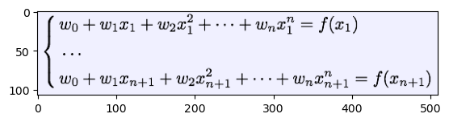

```python
i = Image.open('sys.png')
sys = np.array(i)
plot.imshow(sys) # мне лень это техать, поэтому воспользуемся полученными знаниями)))
```

где через $x_1, ..., x_n, x_{n+1}$ обозначены точки, через которые проходит многочлен, а через $f(x_1), ..., f(x_n), f(x_{n+1})$ — значения, которые он должен принимать в этих точках.

Воспользуемся описанным свойством, и будем находить приближение функции многочленом, решая систему линейных уравнений.

1. Сформируйте систему линейных уравнений (то есть задайте матрицу коэффициентов A и свободный вектор b) для многочлена первой степени, который должен совпадать с функцией f в точках 1 и 15. Решите данную систему с помощью функции scipy.linalg.solve. Нарисуйте функцию f и полученный многочлен. Хорошо ли он приближает исходную функцию?
2. Повторите те же шаги для многочлена второй степени, который совпадает с функцией f в точках 1, 8 и 15. Улучшилось ли качество аппроксимации?
3. Повторите те же шаги для многочлена третьей степени, который совпадает с функцией f в точках 1, 4, 10 и 15. Хорошо ли он аппроксимирует функцию? Коэффициенты данного многочлена (четыре числа в следующем порядке: w_0, w_1, w_2, w_3) являются ответом на задачу. Округлять коэффициенты не обязательно, но при желании можете произвести округление до второго знака (т.е. до числа вида 0.42)

```
[[ 1  1]
 [ 1 15]]
[ 3.43914511 -0.18692825]
```

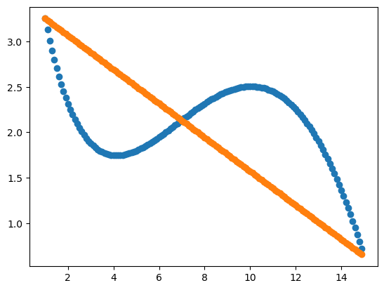

```
[[  1   1   1]
 [  1   8  64]
 [  1  15 225]]
[ 3.32512949 -0.06531159 -0.00760104]
```

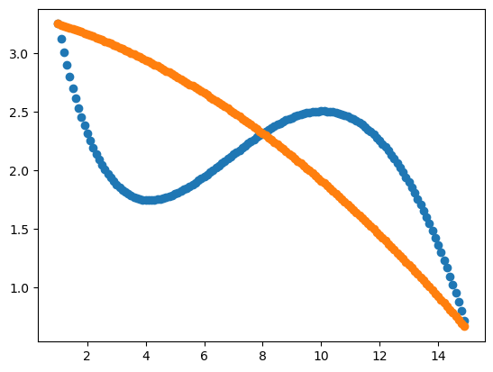

```
[[   1    1    1    1]
 [   1    4   16   64]
 [   1   10  100 1000]
 [   1   15  225 3375]]
[ 4.36264154 -1.29552587  0.19333685 -0.00823565]
```

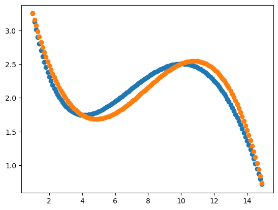

```python
import scipy.linalg #будем решать СЛАУ
def f(x):
    return np.sin(x/5) * np.exp(x/10) + 5*np.exp(-x/2)
def ap(xi): # xi - массив точек, в которых приближаем, число точек - степень многочлена +1
    f_ap = np.array(list(map(f, xi)))
    A = []
    for x in xi:
        A.append([])
        for j in range(len(xi)):
            A[-1].append(x**j)
    A = np.array(A)
    print(A)
    u = scipy.linalg.solve(A, f_ap)
    print(u)
    X = np.arange(1, 15, 0.1)
    F = []
    Px = []
    for x in X:
        F.append(f(x))
        Px.append(0)
        for j in range(len(u)):
            Px[-1] += u[j] * x**j #формируем многочлен Р(х)
    F = np.array(F)
    Px = np.array(Px)
    plot.scatter(X, F) #рисуем оригинал
    plot.scatter(X, Px) #рисуем приближение
    plot.show()
ap([1, 15])
ap([1, 8, 15])
ap([1, 4, 10, 15]) #этот лучше всего ложится
```